# Distributions

Brian

15 August 2015

# r,d,q,p in R

R comes with a rich set of probability distributions, and four consistent ways of accessing them: r, d, q, and p. If you combine these with the name of the distribution - rnorm(), dnorm(), qnorm(), and pnorm(), for example - you can generate random numbers, find the value of the function at a specific point, produce a critical value, and calculate a p-value.

### r

When you want to generate random numbers, use the r prefix, as in rf() for the F distribution. Most distributions require one or more parameters to define the shape of the distribution. For the F distribution, you need the degrees of freedom for the numerator (df1) and the denominator (df2). To generate n=50 random numbers;

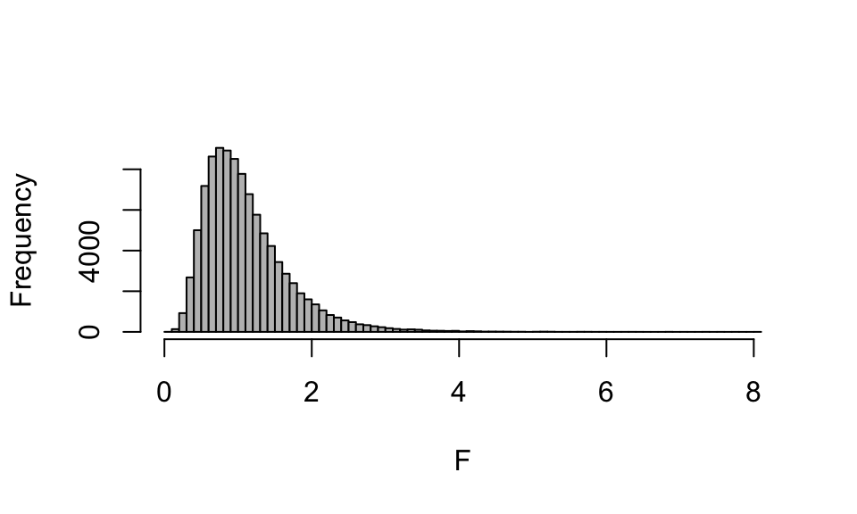

```
##  [1] 0.8789351 1.6148399 0.9380770 1.5534146 0.8880941 0.6275633 0.6098439
##  [8] 1.2294668 0.7982342 1.1478039 1.0184915 1.0544140 1.5568695 0.9969349
## [15] 0.9570566 2.0908959 1.0070234 0.7432159 1.6879443 2.2301810 1.1459661
## [22] 0.7737277 1.3615348 1.0612389 2.6917456 1.1375826 1.0858923 0.6309453
## [29] 0.4346352 1.6889620 2.3529756 0.5904081 0.5582149 1.5210677 0.9355450
## [36] 1.2086088 0.9354494 1.5244775 3.0561347 1.0264522 0.5128519 1.0292168
## [43] 1.3348006 0.8664211 3.2272642 1.2313632 1.4980895 2.4252850 1.4696435
## [50] 2.1606670
```

```r
rf(n=50, df1=15, df2=20)
hist(rf(100000, df1=15, df2=20), breaks=100, col="gray", xlab="F", main="")
```

### d

The d prefix, such as df(), is useful for finding the value of the F function, called its density, at any value of the statistic. Useful to look at the shape o fa curve also from a sequence.

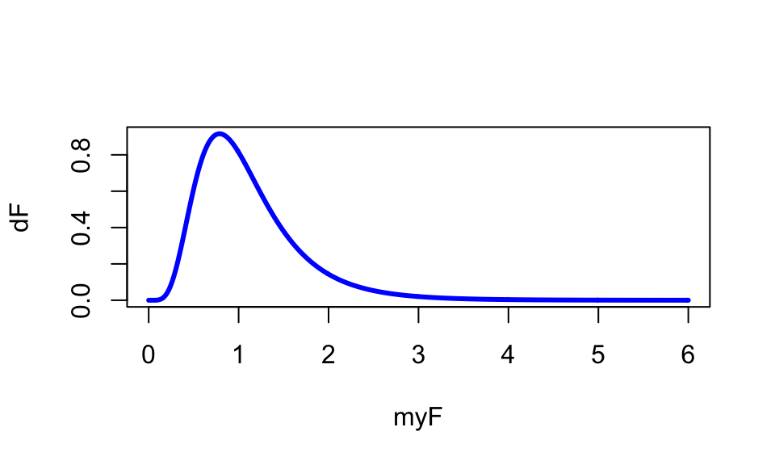

```
## [1] 0.07871035
```

```r
df(x=2.3, df1=15, df2=20)
myF <- seq(from=0, to=6, by=0.01)
dF <- df(x=myF, df1=15, df2=20)
plot(myF, dF, type="l", lwd=3, col="blue")
```

### q

The q prefix, as in qf(), is how you obtain critical values from a probability distribution. By default, R will integrate the probability starting from the left tail. If you want to get the probability starting from the right tail, be sure to set lower.tail=FALSE.

```r
alpha = 0.05
qf(p=alpha, df1=15, df2=20, lower.tail=FALSE)
```

```
## [1] 2.203274
```

p The p prefix, as in pf(), is how you calculate a p-value from a probability distribution. As for the q prefix, R will always integrate starting with the lower tail. If you want the right tail, specify lower.tail=FALSE. Specify the value of F for which you want a p-value, the degrees of freedom, and whether you want the left tail or the right tail.

```r
observedF = 3.7
pf(q=observedF, , df1=15, df2=20, lower.tail=FALSE)
```

```
## [1] 0.003637118
```

# Normal Distribution

The normal distribution appears in many biological and other process. It is symetrical and is formed by the *central limit theorem* Many random effects will be approximately normally distributed. So peoples height, weight etc.

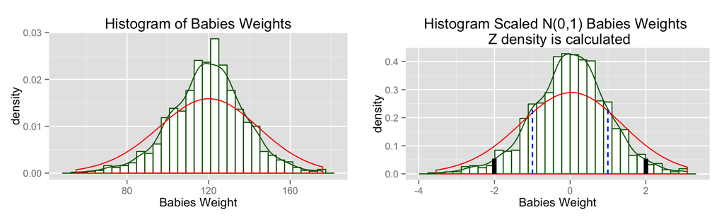

# Chi Squared Distribution

If you sample from a normal distribution and sqaure the results you will get a $\chi^{2}$ distribution. More formally $X \sim \aleph(0,1)$. Depending on the number of samples that are taken, the degrees of freedom pushes the probablity density distribution to the right until it forms a normal distribution itself.

The distribution is additive. Therefore $\chi^2_1=X^2_1 \:and\: \chi^2_2=X^2_1+X^2_2$ etc.

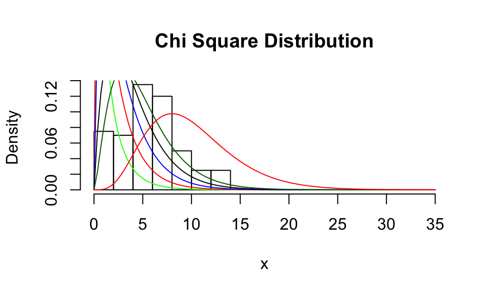

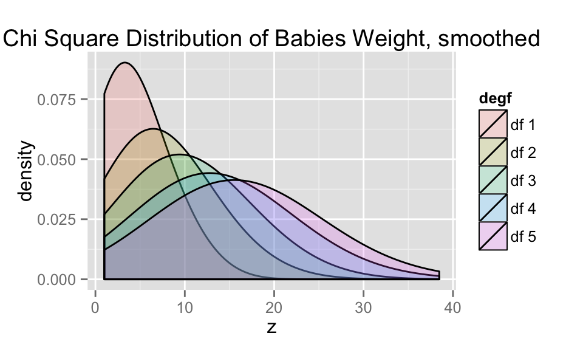

# F Distribtuion

If V 1 and V 2 are two independent random variables having the Chi-Squared distribution with m1 and m2 degrees of freedom respectively, then the following quantity follows an F distribution with m1 numerator degrees of freedom and m2 denominator degrees of freedom, i.e., (m1,m2) degrees of freedom.

$F = \frac{V1_{m1}}{V2_{m2}} \sim F_{(m1,m2)}$

F and chi-squared statistics are really the same thing in that, after a normalization, chi-squared is the limiting distribution of the F as the denominator degrees of freedom goes to infinity. The normalization is chi-squared = (numerator degrees of freedom) * F.

```r
qf(.95, df1=5, df2=2)


#F Distribution - right probability
1-pf(2.05,df1=2,df2=71)
1-pf(2.05,df1=2,df2=150)
1-pf(2.05,df1=2,df2=1500)
1-pf(2.05,df1=2,df2=15000)

#Significant value
qf(0.95,df1=2,df2=71)
qf(0.95,df1=2,df2=15000)


1-pchisq(4.05, df=2)

qchisq(0.1287,df=2)

1-pchisq(3,2)
```

```
## [1] 19.29641
## [1] 0.1362867
## [1] 0.1323264
## [1] 0.1290954
## [1] 0.128771
## [1] 3.125764
## [1] 2.996331
## [1] 0.1319938
## [1] 0.2755379
## [1] 0.2231302
```